# Cell2Cell | Logistic Regression

```r
library(tidyverse)
```

## Preprocessing

Use the generated_data and split manifest to get the training, validation, and test sets.

```r
source("R/preprocessing.R")

cleaned <- read.csv("Generated_Data/cleaned_data.csv", na.strings = c("", "NA"))
manifest <- read.csv("Generated_Data/split_manifest.csv")
stopifnot(
  !anyDuplicated(cleaned$CustomerID),
  !anyDuplicated(manifest$CustomerID),
  setequal(cleaned$CustomerID, manifest$CustomerID)
)
data <- cleaned[match(manifest$CustomerID, cleaned$CustomerID),]
data$split <- manifest$split
data$cv_fold <- manifest$cv_fold
data <- add_cell2cell_features(data)

# Separate training and test data
training <- subset(data, split == "train")
test <- subset(data, split == "test")

stopifnot(
  !anyNA(training$cv_fold),
  setequal(unique(training$cv_fold), 1:3),
  all(is.na(test$cv_fold))
)

table(training$cv_fold)
```

```
##
##     1     2     3
## 12762 12762 12761
```

```r
table(training$Churn)
```

```
##
##    No   Yes
## 27252 11033
```

```r
# dimensions
dim(training)
```

```
## [1] 38285    65
```

```r
dim(test)
```

```
## [1] 12762    65
```

There are three recommended predictor sets for the logistic regression model. I will train a model using each predictor set at each outreach capacity (0.1, 0.2, 0.3).

The predictor set labelled `focused_both` contains the following variables. Among all predictor sets, MonthsInService is transformed using a natural cubic spline (df = 3).

`focused_both` contains the interaction term between `MonthsInSerive` and `CurrentEquipmentDays`.

`focused_missing` contains the same features but without this interaction term.

`broader_without_price` is the same set of features as before but with additional features such as handset information, usage costs and roaming, customer history, and calling activity.

```r
# Retrieve logistic regression predictor groups
handoff_predictors <- cell2cell_handoff_predictors()
logistic_terms <- handoff_predictors$logistic

logistic_terms$focused_both
```

```
##  [1] "splines::ns(MonthsInService, df = 3)"
##  [2] "CurrentEquipmentDays"
##  [3] "PercChangeMinutes"
##  [4] "DroppedCalls"
##  [5] "BlockedCalls"
##  [6] "CustomerCareCalls"
##  [7] "MonthlyRevenue"
##  [8] "PercChangeRevenues"
##  [9] "billing_gap"
## [10] "UniqueSubs"
## [11] "ActiveSubs"
## [12] "HandsetWebCapable"
## [13] "UsageChangeMissing"
## [14] "splines::ns(MonthsInService, df = 3):CurrentEquipmentDays"
```

```r
logistic_terms$focused_missing
```

```
##  [1] "splines::ns(MonthsInService, df = 3)"
##  [2] "CurrentEquipmentDays"
##  [3] "PercChangeMinutes"
##  [4] "DroppedCalls"
##  [5] "BlockedCalls"
##  [6] "CustomerCareCalls"
##  [7] "MonthlyRevenue"
##  [8] "PercChangeRevenues"
##  [9] "billing_gap"
## [10] "UniqueSubs"
## [11] "ActiveSubs"
## [12] "HandsetWebCapable"
## [13] "UsageChangeMissing"
```

```r
logistic_terms$broader_without_price
```

```
##  [1] "splines::ns(MonthsInService, df = 3)"
##  [2] "CurrentEquipmentDays"
##  [3] "PercChangeMinutes"
##  [4] "DroppedCalls"
##  [5] "BlockedCalls"
##  [6] "CustomerCareCalls"
##  [7] "MonthlyRevenue"
##  [8] "PercChangeRevenues"
##  [9] "billing_gap"
## [10] "HandsetWebCapable"
## [11] "HandsetRefurbished"
## [12] "Handsets"
## [13] "HandsetModels"
## [14] "RoamingCalls"
## [15] "OverageMinutes"
```

[output cut: 16 more lines]

```r
# Three candidate models
model_terms <- list(
  focused_both = logistic_terms$focused_both,
  focused_missing = logistic_terms$focused_missing,
  broader_without_price = logistic_terms$broader_without_price
)

# Convert predictor lists into formulas
model_formulas <- lapply(
  model_terms,
  function(terms) {
    reformulate(terms, response = "churn_flag")
  }
)
# View the three formulas
# model_formulas
```

```r
# All unique predictors used across the three models
inputs <- unique(unlist(
  lapply(unlist(model_terms, use.names = FALSE), function(term) {
    all.vars(parse(text = term))
  }),
  use.names = FALSE
))
```

The model is evaluated on three outreach capacities, which looks for customers in the top 10%, 20%, and 30% highest risk of churning.

```r
capacities <- c(0.10, 0.20, 0.30)

evaluate_logistic <- function(actual,probability,customer_id,model_name,fold_id) {

  outcome <- as.numeric(as.character(actual))

  positives <- sum(outcome == 1) # churned
  negatives <- sum(outcome == 0) # did not churn

  stopifnot(
    !anyNA(outcome),
    positives > 0,
    negatives > 0
  )
  # auc formula
  auc <- (
    sum(rank(probability)[outcome == 1]) -
      positives * (positives + 1) / 2
  ) / (positives * negatives)
  # customer ranking
  ranked <- order(-probability, customer_id)

  # Evaluate different outreach capacities
  precision <- vapply(capacities, function(capacity) {
    n_contact <- floor(capacity * length(ranked))
    contacted <- head(ranked, n_contact)
    mean(outcome[contacted] == 1)
  }, numeric(1))

  # Lift relative to overall churn rate
  lift <- precision / mean(outcome == 1)

  data.frame(
    Model = model_name,
    Fold = fold_id,
    Capacity = capacities,
    AUC = auc,
    Precision = precision,
    Lift = lift
  )
}
```

### Three-fold Validation Step

```r
fold_results <- list()
fold_models <- list()

for (fold_id in 1:3) {
  cat("Validation fold:", fold_id, "\n")

  # Split analysis and assessment data
  analysis <- training[training$cv_fold != fold_id, ] # training fold
  assessment <- training[training$cv_fold == fold_id, ] # validation fold

  # Preprocess using analysis data only
  processed <- prepare_cell2cell_fold(
    analysis,
    assessment,
    inputs
  )
  analysis <- processed$analysis
  assessment <- processed$assessment

  # Fit and evaluate all three models
  fold_results[[fold_id]] <- do.call(
    rbind,
    lapply(names(model_terms), function(candidate) {

      formula <- model_formulas[[candidate]]

      # Fit logistic regression
      fit <- glm(
        formula,
        family = binomial(),
        data = analysis,
        na.action = na.fail
      )
      stopifnot(
        fit$converged,
        nobs(fit) == nrow(analysis)
      )

      # Predict churn probabilities
      probability <- predict(
        fit,
        newdata = assessment,
        type = "response"
      )
      stopifnot(
        length(probability) == nrow(assessment),
        all(is.finite(probability))
      )

      # Evaluate model
      results <- evaluate_logistic(
        actual = assessment$churn_flag,
        probability = probability,
        customer_id = assessment$CustomerID,
        model_name = candidate,
        fold_id = fold_id
      )

      # Save fitted model
      fold_models[[paste(candidate, fold_id, sep = "_")]] <<- fit

      results
    })
  )
}
```

```
## Validation fold: 1
## Validation fold: 2
## Validation fold: 3
```

```r
# Combine results from all folds
fold_scores <- do.call(rbind, fold_results)
row.names(fold_scores) <- NULL
fold_scores
```

```
##                    Model Fold Capacity       AUC Precision     Lift
## 1           focused_both    1      0.1 0.6128119 0.4239812 1.471139
## 2           focused_both    1      0.2 0.6128119 0.3844044 1.333814
## 3           focused_both    1      0.3 0.6128119 0.3764368 1.306168
## 4        focused_missing    1      0.1 0.6100918 0.3981191 1.381402
## 5        focused_missing    1      0.2 0.6100918 0.3793103 1.316139
## 6        focused_missing    1      0.3 0.6100918 0.3649425 1.266285
## 7  broader_without_price    1      0.1 0.6170152 0.4090909 1.419472
## 8  broader_without_price    1      0.2 0.6170152 0.3902821 1.354209
## 9  broader_without_price    1      0.3 0.6170152 0.3759143 1.304355
## 10          focused_both    2      0.1 0.6139285 0.4224138 1.465700
## 11          focused_both    2      0.2 0.6139285 0.3957680 1.373244
## 12          focused_both    2      0.3 0.6139285 0.3761755 1.305262
## 13       focused_missing    2      0.1 0.6113923 0.4247649 1.473858
## 14       focused_missing    2      0.2 0.6113923 0.3859718 1.339253
## 15       focused_missing    2      0.3 0.6113923 0.3696447 1.282601
## 16 broader_without_price    2      0.1 0.6134932 0.4145768 1.438507
## 17 broader_without_price    2      0.2 0.6134932 0.3844044 1.333814
## 18 broader_without_price    2      0.3 0.6134932 0.3725183 1.292572
## 19          focused_both    3      0.1 0.6250053 0.4459248 1.547578
## 20          focused_both    3      0.2 0.6250053 0.4086991 1.418387
## 21          focused_both    3      0.3 0.6250053 0.3806165 1.320927
## 22       focused_missing    3      0.1 0.6211680 0.4451411 1.544859
## 23       focused_missing    3      0.2 0.6211680 0.3949843 1.370790
## 24       focused_missing    3      0.3 0.6211680 0.3725183 1.292822
## 25 broader_without_price    3      0.1 0.6191574 0.4043887 1.403428
## 26 broader_without_price    3      0.2 0.6191574 0.3898903 1.353111
## 27 broader_without_price    3      0.3 0.6191574 0.3753918 1.302795
```

```r
cv_summary <- aggregate(
  cbind(AUC, Precision, Lift) ~ Model + Capacity,
  data = fold_scores,
  FUN = mean
)

# Calculate standard deviation across folds
cv_sd <- aggregate(
  cbind(AUC, Precision, Lift) ~ Model + Capacity,
  data = fold_scores,
  FUN = sd
)

names(cv_sd)[names(cv_sd) == "AUC"] <- "AUC_SD"
names(cv_sd)[names(cv_sd) == "Precision"] <- "Precision_SD"
names(cv_sd)[names(cv_sd) == "Lift"] <- "Lift_SD"

# Combine mean and standard deviation
cv_summary <- merge(
  cv_summary,
  cv_sd,
  by = c("Model", "Capacity")
)

cv_summary <- cv_summary[
  order(
    -cv_summary$Precision,
    -cv_summary$AUC,
    -cv_summary$Lift
  ),
]

print(cv_summary, row.names = FALSE)
```

```
##                  Model Capacity       AUC Precision     Lift      AUC_SD
##           focused_both      0.1 0.6172486 0.4307732 1.494806 0.006740726
##        focused_missing      0.1 0.6142174 0.4226750 1.466706 0.006054446
##  broader_without_price      0.1 0.6165553 0.4093521 1.420469 0.002859973
##           focused_both      0.2 0.6172486 0.3962905 1.375148 0.006740726
##  broader_without_price      0.2 0.6165553 0.3881923 1.347045 0.002859973
##        focused_missing      0.2 0.6142174 0.3867555 1.342061 0.006054446
##           focused_both      0.3 0.6172486 0.3777429 1.310785 0.006740726
##  broader_without_price      0.3 0.6165553 0.3746082 1.299907 0.002859973
##        focused_missing      0.3 0.6142174 0.3690352 1.280569 0.006054446
##  Precision_SD     Lift_SD
##   0.013144980 0.045783345
##   0.023580531 0.081962703
##   0.005099065 0.017560843
##   0.012155759 0.042318484
##   0.003286245 0.011471136
##   0.007866324 0.027433579
##   0.002492004 0.008794212
##   0.001828631 0.006400481
##   0.003824485 0.013384512
```

Based on the summary, focused_both model provides the highest precision and AUC at 10% outreach capacity. Let us explore this group more by training it on the full training data and validating it on the test data.

### Final Logistic Regression Model

```r
# Preprocess full training data and reserved test data
final_processed <- prepare_cell2cell_fold(
  training,
  test,
  inputs
)

final_training <- final_processed$analysis
final_test <- final_processed$assessment

# Select focused_both
selected_model <- "focused_both"

# Fit logistic regression
final_logit <- glm(
  model_formulas[[selected_model]],
  family = binomial(),
  data = final_training,
  na.action = na.fail
)

# Inspect model summary
# summary(final_logit)
```

```r
test_results <- evaluate_logistic(
  actual = final_test$churn_flag,
  probability = predict(
    final_logit,
    newdata = final_test,
    type = "response"
  ),
  customer_id = final_test$CustomerID,
  model_name = "focused_both",
  fold_id = "Test"
)

print(test_results, row.names = FALSE)
```

```
##         Model Fold Capacity       AUC Precision     Lift
##  focused_both Test      0.1 0.6184185 0.4310345 1.495612
##  focused_both Test      0.2 0.6184185 0.4059561 1.408595
##  focused_both Test      0.3 0.6184185 0.3787879 1.314326
```

The results are consistent with the previous results.

### Test Data

```r
test_predictions <- data.frame(
  CustomerID = final_test$CustomerID,
  Actual_Churn = final_test$Churn,
  focused_both_Probability = predict(
    final_logit,
    newdata = final_test,
    type = "response"
  )
)

head(test_predictions)
```

```
##    CustomerID Actual_Churn focused_both_Probability
## 8     3000042           No                0.2557867
## 11    3000054           No                0.2649960
## 13    3000062           No                0.2388952
## 20    3000126           No                0.3061576
## 24    3000142           No                0.2506358
## 25    3000146           No                0.2593338
```

```r
# saves the prediction dataframe as a csv
#write.csv(test_predictions, file = "predicted_probabilities/logistic_predictions.csv", row.names = FALSE)
```

### Confusion Matrix

```r
# Get predicted probabilities
test_probability <- predict(
  final_logit,
  newdata = final_test,
  type = "response"
)

# Function to calculate confusion matrix at an outreach capacity
get_churn_matrix <- function(actual, probability, capacity) {

  # Determine probability cutoff for the selected capacity
  cutoff <- quantile(
    probability,
    probs = 1 - capacity,
    type = 1
  )

  # Rank customers by predicted probability
  predicted <- ifelse(probability >= cutoff, 1, 0)

  # Create confusion matrix
  table(
    Actual = factor(actual, levels = c(0, 1)),
    Predicted = factor(predicted, levels = c(0, 1))
  )
}

# Calculate matrices
matrix_10 <- get_churn_matrix(
  final_test$churn_flag,
  test_probability,
  0.10
)

matrix_20 <- get_churn_matrix(
  final_test$churn_flag,
  test_probability,
  0.20
)

matrix_30 <- get_churn_matrix(
  final_test$churn_flag,
  test_probability,
  0.30
)

# Display confusion matrices
cat("Top 10% outreach capacity\n")
```

```
## Top 10% outreach capacity
```

```r
matrix_10 # confusion matrix for 10% outreach capacity
```

```
##       Predicted
## Actual    0    1
##      0 8357  727
##      1 3128  550
```

```r
cat("Top 20% outreach capacity\n")
```

```
## Top 20% outreach capacity
```

```r
matrix_20 # confusion matrix for 20% outreach capacity
```

```
##       Predicted
## Actual    0    1
##      0 7567 1517
##      1 2642 1036
```

```r
cat("Top 30% outreach capacity\n")
```

```
## Top 30% outreach capacity
```

```r
matrix_30 # confusion matrix for 30% outreach capacity
```

```
##       Predicted
## Actual    0    1
##      0 6705 2379
##      1 2228 1450
```

# Estimated Net Revenue

The following assumptions are made:

Retention success rate will range from (0.15, 0.25, 0.35, 0.45)

Contact cost will range from (2, 3, 4, 5)

Offer cost is the additional cost of the retention incentive given to a customer to encourage them to stay. It can be credit given to the customer, discounts, or additional service. For example, if the offer is 10 dollars off from current monthly plan cost for 3 months, then offer cost would be 30 dollars.

```r
# Fixed outreach capacity
outreach_capacity <- 0.10

# Business assumptions to test
churn_rates <- c(0.15, 0.25, 0.30, 0.40)
retention_success_rates <- c(0.15, 0.25, 0.35, 0.45)
contact_costs <- c(2, 3, 4, 5)

# Retention offer cost
offer_costs <- c(0, 20, 30, 50)

# Revenue projection period. This assumes that the customer will stay for the next 12 months after accepting an offer
projection_months <- 12
```

```r
# Predict churn probabilities on the test set
test_probability <- predict(
  final_logit,
  newdata = final_test,
  type = "response"
)

# Observed churn rate in the training dataset
sample_churn_rate <- mean(
  as.numeric(as.character(training$churn_flag))
)

sample_churn_rate
```

```
## [1] 0.2881807
```

Adjusts the model’s predicted churn probabilities to reflect an assumed real-world churn rate.

```r
adjust_probabilities <- function(probability, sample_rate, target_rate) {

  sample_odds <- probability / (1 - probability)

  adjusted_odds <- sample_odds *
    (target_rate / (1 - target_rate)) /
    (sample_rate / (1 - sample_rate))

  adjusted_probability <- adjusted_odds / (1 + adjusted_odds)

  adjusted_probability
}
```

Calculate Net Revenue for each combination of the assumptions.

```r
# Create all combinations of assumptions
scenarios <- expand.grid(
  Churn_Rate = churn_rates,
  Retention_Success_Rate = retention_success_rates,
  Contact_Cost = contact_costs,
  Offer_Cost = offer_costs
)

# Customer monthly revenue
monthly_revenue <- as.numeric(final_test$MonthlyRevenue)

# Number of customers to contact
n_contact <- floor(nrow(final_test) * outreach_capacity)

# Calculate revenue for each scenario
revenue_results <- do.call(
  rbind,
  lapply(seq_len(nrow(scenarios)), function(i) {

    scenario <- scenarios[i, ]

    # Adjust probabilities to the assumed real-world churn rate
    adjusted_probability <- adjust_probabilities(
      probability = test_probability,
      sample_rate = sample_churn_rate,
      target_rate = scenario$Churn_Rate
    )

    # Calculate expected monthly revenue at risk
    value_at_risk <- adjusted_probability * monthly_revenue

    # Rank customers by revenue at risk
    ranked_customers <- order(
      -value_at_risk,
      final_test$CustomerID
    )

    # Select customers within outreach capacity
    contacted <- head(ranked_customers, n_contact)

    # Expected number of at-risk customers contacted
    expected_at_risk <- sum(
      adjusted_probability[contacted]
    )

    # Expected number of customers retained
    expected_retained <- expected_at_risk *
      scenario$Retention_Success_Rate

    # Expected 12-month revenue saved
    revenue_saved <- sum(
      adjusted_probability[contacted] *
        scenario$Retention_Success_Rate *
        monthly_revenue[contacted] *
        projection_months
    )

    # Total campaign cost
    campaign_cost <- n_contact * (
      scenario$Contact_Cost + scenario$Offer_Cost
    )

    # Net revenue
    net_revenue <- revenue_saved - campaign_cost

    data.frame(
      Churn_Rate = scenario$Churn_Rate,
      Retention_Success_Rate = scenario$Retention_Success_Rate,
      Contact_Cost = scenario$Contact_Cost,
      Offer_Cost = scenario$Offer_Cost,
      Customers_Contacted = n_contact,
      Expected_At_Risk = expected_at_risk,
      Expected_Retained = expected_retained,
      Revenue_Saved = revenue_saved,
      Campaign_Cost = campaign_cost,
      Net_Revenue = net_revenue
    )
  })
)
row.names(revenue_results) <- NULL
```

In the most obvious sense, Net Revenue is highest when Churn Rate and Retention Rate is high. There are more customers who can potentially be ‘saved’ by the ‘offer,’ The higher retention rate means that more of these customers accepted the offer. However, this is the most optimistic scenario.

```r
revenue_results |>
  arrange(desc(Net_Revenue)) |>
  head(10)
```

```
##    Churn_Rate Retention_Success_Rate Contact_Cost Offer_Cost
## 1         0.4                   0.45            2          0
## 2         0.4                   0.45            3          0
## 3         0.4                   0.45            4          0
## 4         0.4                   0.45            5          0
## 5         0.4                   0.45            2         20
## 6         0.4                   0.45            3         20
## 7         0.4                   0.45            4         20
## 8         0.4                   0.45            5         20
## 9         0.4                   0.45            2         30
## 10        0.4                   0.45            3         30
##    Customers_Contacted Expected_At_Risk Expected_Retained Revenue_Saved
## 1                 1276         573.5367          258.0915      449744.9
## 2                 1276         573.5367          258.0915      449744.9
## 3                 1276         573.5367          258.0915      449744.9
```

[output cut: 18 more lines]

```r
# saves the scenario dataframe as a csv
# write.csv(revenue_results, file = "revenue_scenarios/logistic_revenue_estimates.csv", row.names = FALSE)
```

This may not be the most logical since it assumes that churn rate and retention rate is high.

```r
best_scenario <- revenue_results[
  which.max(revenue_results$Net_Revenue),
]

print(best_scenario, row.names = FALSE)
```

```
##  Churn_Rate Retention_Success_Rate Contact_Cost Offer_Cost Customers_Contacted
##         0.4                   0.45            2          0                1276
##  Expected_At_Risk Expected_Retained Revenue_Saved Campaign_Cost Net_Revenue
##          573.5367          258.0915      449744.9          2552    447192.9
```

```r
# Average net revenue by assumed churn rate
aggregate(
  Net_Revenue ~ Churn_Rate,
  data = revenue_results,
  FUN = mean
)
```

```
##   Churn_Rate Net_Revenue
## 1       0.15     89066.0
## 2       0.25    161688.7
## 3       0.30    196344.2
## 4       0.40    263463.9
```

```r
# Average net revenue by retention success rate
aggregate(
  Net_Revenue ~ Retention_Success_Rate,
  data = revenue_results,
  FUN = mean
)
```

```
##   Retention_Success_Rate Net_Revenue
## 1                   0.15    70637.36
## 2                   0.25   141972.93
## 3                   0.35   213308.50
## 4                   0.45   284644.07
```

```r
# Average net revenue by contact cost
aggregate(
  Net_Revenue ~ Contact_Cost,
  data = revenue_results,
  FUN = mean
)
```

```
##   Contact_Cost Net_Revenue
## 1            2    179554.7
## 2            3    178278.7
## 3            4    177002.7
## 4            5    175726.7
```

```r
# Average net revenue by offer cost
aggregate(
  Net_Revenue ~ Offer_Cost,
  data = revenue_results,
  FUN = mean
)
```

```
##   Offer_Cost Net_Revenue
## 1          0    209540.7
## 2         20    184020.7
## 3         30    171260.7
## 4         50    145740.7
```

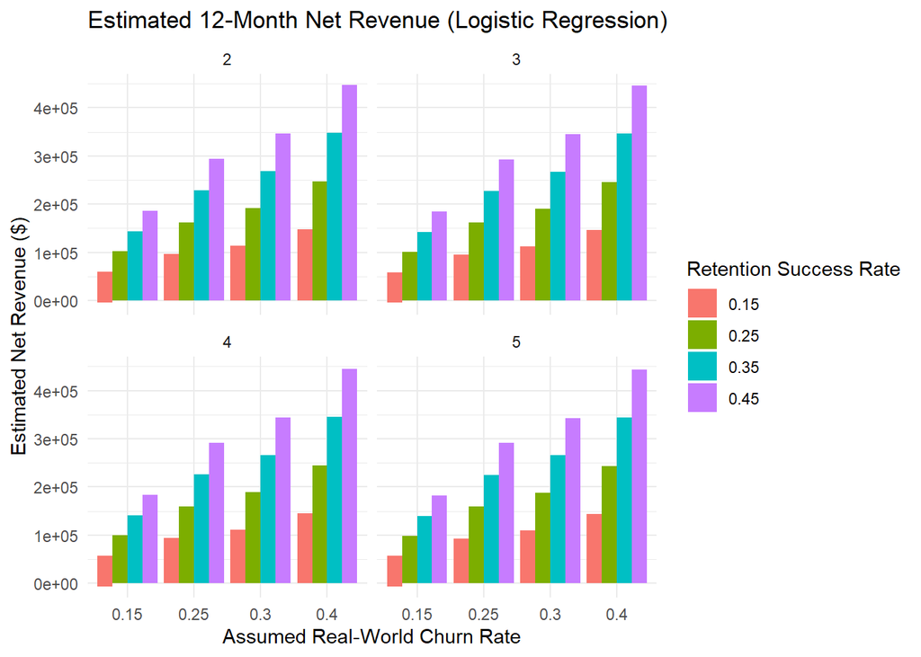

```r
library(ggplot2)

ggplot(
  revenue_results,
  aes(
    x = factor(Churn_Rate),
    y = Net_Revenue,
    fill = factor(Retention_Success_Rate)
  )
) +
  geom_col(position = "dodge") +
  facet_wrap(~ Contact_Cost) +
  labs(
    title = "Estimated 12-Month Net Revenue (Logistic Regression)",
    x = "Assumed Real-World Churn Rate",
    y = "Estimated Net Revenue ($)",
    fill = "Retention Success Rate"
  ) +
  theme_minimal()
```